# HW6_B04701204_ANOVA

B04701204

2017年12月6日

## 題目：探討不同酒種是否影響其中的類黃酮含量 - ANOVA 分析

### 資料輸入 - Wine Dataset

從 LIBSVM Data 取得 wine dataset (https://www.csie.ntu.edu.tw/~cjlin/libsvmtools/datasets/multiclass/wine.scale)。 透過`read.libsvm.R` 讀入資料並整理之。

```r
#read in the data and convert to dataframe
source( 'read.libsvm.R' )
```

```r
wine = read.libsvm( 'wine.scale', 13 )
wine = as.data.frame(wine)

#reassign attributes
names(wine) = c("type","alc","acid","ash","alk","mag","phenols","flav","nonflav","proanth","color","hue","OD","proline")

#encode wine type as factor
wine$type = as.factor(wine$type)
```

### 套件執行

```r
require(ggplot2)
library(Hmisc)
library(base)
```

### 繪圖

根據英美的醫學報告https://www.ncbi.nlm.nih.gov/pubmed/28714503，男性經常食用富含類黃酮(flavonoids)的食品， 可顯著降低罹患帕金森氏症的風險。透過ANOVA分析，本題將就 wine dataset探討不同酒種對類黃酮含量的影響。在進行分析前， 先繪製盒鬚圖(boxplot)與平均值加上信賴區間(interval plot)以觀察類黃酮含量在不同酒種間的分布。

#### 盒鬚圖 (boxplot)

製作盒鬚圖。

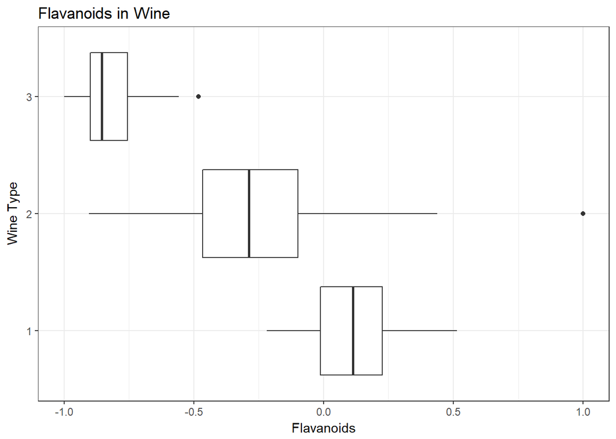

```r
#set black-white theme
old <- theme_set(theme_bw())

#plot boxplot
ggplot(data = wine, aes(x = type, y = flav)) +
  geom_boxplot() + coord_flip() +
  labs( y = 'Flavanoids', x = 'Wine Type',
        title = 'Flavanoids in Wine')
```

#### 平均值加上信賴區間 (interval plot)

```r
#compute standardized mean of flav for different wine types
tapply(wine$flav, wine$type, mean)
```

```
##          1          2          3
##  0.1149253 -0.2654662 -0.8137306
```

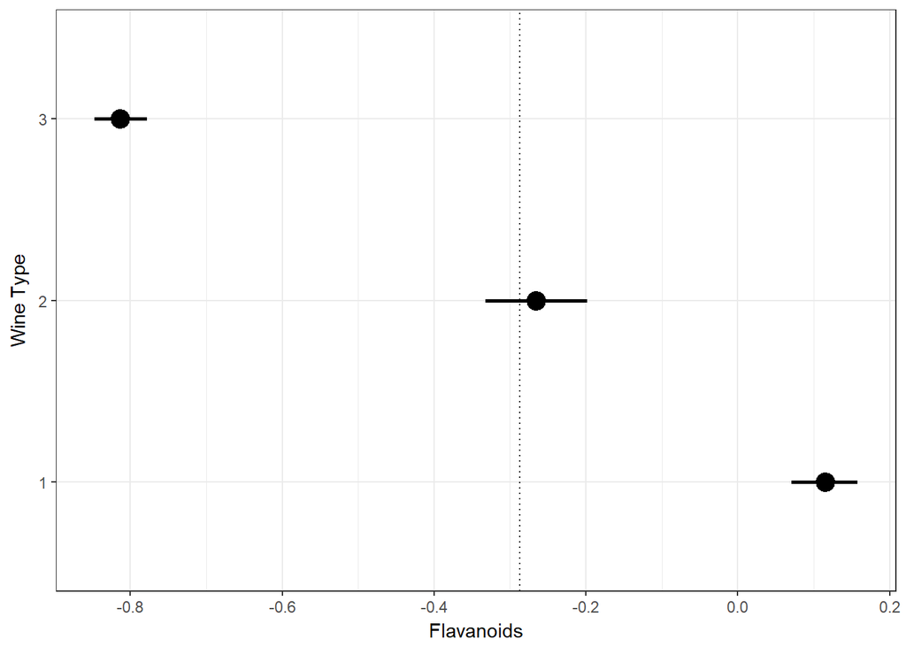

```r
#plot interval plot
ggplot(data = wine,
       aes(x = type, y = flav))+
  stat_summary(fun.data = 'mean_cl_boot', size = 1) +
  scale_y_continuous(breaks = seq(-1, 0.2, by = 0.2))+
  geom_hline(yintercept = mean(wine$flav) ,
             linetype = 'dotted') +
  labs(x = 'Wine Type', y = 'Flavanoids') +
  coord_flip()
```

從上述兩張繪圖，可以看出類黃酮含量因酒種不同而有顯著的差異。

### ANOVA 分析

因為有三各類別的酒種，因此採用 ANOVA 分析探討類黃酮含量(連續型之因變量)與酒種(類別型之自變量)的關係， 再次檢驗上述繪圖的結論。

H0：mu1 = mu2 = mu3 ，表示樣本平均數的差異無顯著性，即酒種對類黃酮含量無顯著影響。

```r
#ANOVA test
anova(m1 <- lm(flav ~ type, data = wine))
```

```
## Analysis of Variance Table
##
## Response: flav
##            Df  Sum Sq Mean Sq F value    Pr(>F)
## type        2 22.8814 11.4407  233.93 < 2.2e-16 ***
## Residuals 175  8.5588  0.0489
## ---
## Signif. codes:  0 '***' 0.001 '**' 0.01 '*' 0.05 '.' 0.1 ' ' 1
```

```r
summary(m1)$r.squared
```

```
## [1] 0.7277755
```

p-value=2.2e-16<0.05故 reject null hypothesis H0, 證實類黃酮含量因酒種不同而有顯著差異，呼應上述繪圖的結論。